# TEKRABber

Yao-Chung Chen and Katja Nowick

Human Biology, Institute of Biology, Freie Universität Berlin, Berlin, Germany

katja.nowick@fu-berlin.de

12 January 2022

#### Package

TEKRABber 0.99.0

# 1 Introduction

TEKRABber is used to estimate the correlation between genes and transposable elements (TEs) from RNA-seq data comparing between: **(1)** Two Species **(2)** Control vs. Experiment. In the following sections, we will use built-in data to demonstrate how to implement TEKRABber on you own analysis.

# 2 Installation

To use TEKRABber into your R environment, you need to install it using BiocManager:

```r
install.packages("BiocManager")
BiocManager::install("TEKRABber")
```

```r
library(TEKRABber)
library(SummarizedExperiment) # load it if you are running this tutorial
```

# 3 Examples

## 3.1 Comparing between two species, human and chimpanzee as an example

Gene and TE expression data are generated from randomly picked 10 human and 10 chimpanzee brain region FASTQ files (Khrameeva E et al., Genome Research, 2020) using in-house script. The first column of gene and TEs count table must be **Ensembl gene ID** and **TE name**:

```r
# load built-in data
data(speciesCounts)
hmGene <- speciesCounts$hmGene
hmTE <- speciesCounts$hmTE
chimpGene <- speciesCounts$chimpGene
chimpTE <- speciesCounts$chimpTE
# the first column must be Ensembl gene ID for gene, and TE name for TE
head(hmGene)
```

```
##            Geneid SRR8750453 SRR8750454 SRR8750455 SRR8750456 SRR8750457
## 1 ENSG00000000003        250        267        227        286        128
## 2 ENSG00000000005         13          2         15          9          5
## 3 ENSG00000000419        260        311        159        259        272
## 4 ENSG00000000457         86        131        100         94         80
## 5 ENSG00000000460         21         17         42         33         55
## 6 ENSG00000000938        162         75         95        252        195
##   SRR8750458 SRR8750459 SRR8750460 SRR8750461 SRR8750462
## 1        394        268        102        370        244
## 2          0          1          8          0          2
## 3        408        371        126        211        374
## 4        158        119         46         77         81
## 5         29         50         11         18         20
## 6        137         93        108        197         69
```

### 3.1.1 Query ortholog information and estimate scaling factor

In the first step, we use `orthologScale()` to get ortholog information and calculate the scaling factor between two species. The species name needs to be the abbreviation of scientific species name used in Ensembl. (Note: (1)This step queries information using biomaRt and it might need some time or try different mirror due to connection to Ensembl (2)It might take some time to calculate scaling factor based on your data size).

```r
# You can use the code below to search for species name
ensembl <- biomaRt::useEnsembl(biomart = "genes")
biomaRt::listDatasets(ensembl)
```

```r
# In order to save time, we have save the data for this tutorial.
data(fetchDataHmChimp)
fetchData <- fetchDataHmChimp

# If you want to query the data and calculate scaling factor, you can run the code below:
# fetchData <- orthologScale(
#     geneCountRef = hmGene,
#     geneCountCompare = chimpGene,
#     speciesRef = "hsapiens",
#     speciesCompare = "ptroglodytes"
# )
```

### 3.1.2 Create input dataframes for differentially expressed analysis and correlation estimation

We use `DECorrInputs()` to create input files for downstream analysis. This function will create a “./results” directory in your current path to save the input files for next steps.

```r
inputBundle <- DECorrInputs(
    orthologTable = fetchData$orthologTable,
    scaleFactor = fetchData$scaleFactor,
    geneCountRef = hmGene,
    geneCountCompare = chimpGene,
    teCountRef = hmTE,
    teCountCompare = chimpTE
)
```

### 3.1.3 Differentially expressed analysis (DE analysis)

In this step, we need to generate a metadata contain species name (i.e. human and chimpanzee). The row names need to be same as the DE input table and the column name must be **species** (see as the example below). Then we use `DEgeneTE()` to perform DE analysis. The contrastVector parameter needs to be a three element vector. The first item is “species”, the second is the reference species name from metadata which in our case is “human”, and the last one is the compared species in your metadata which is “chimpanzee”. When you are comparing samples between two species, the parameter **expDesign** should be **TRUE** (as default).

```r
meta <- data.frame(
  species = c(rep("human", ncol(hmGene) - 1), rep("chimpanzee", ncol(chimpGene) - 1))
)
meta$species <- factor(meta$species, levels = c("human", "chimpanzee"))
rownames(meta) <- colnames(inputBundle$geneInputDESeq2)
hmchimpDE <- DEgeneTE(
  geneTable = inputBundle$geneInputDESeq2,
  teTable = inputBundle$teInputDESeq2,
  metadata = meta,
  contrastVector = c("species", "human", "chimpanzee"),
  expDesign = TRUE
)
```

### 3.1.4 Correlation analysis

Here we use `corrOrthologTE()` to perform correlation estimation comparing each ortholog and TE. This is the most time consuming step. For a quick demonstration, we use a relatively small size data. You can specify the correlation method and adjusted *p-value* method. Default is Pearson’s correlation with FDR. Please name your output using **.csv** extension and it will generate it in ./results directory. **Note:** For more quick and specific analysis, you can subset your data in this step to focus on only the orthologs and TEs that you are interested in.

```r
# load built-in data
data(speciesCorr)
hmGeneCorrInput <- assay_tekcorrset(speciesCorr, "gene", "human")
hmTECorrInput <- assay_tekcorrset(speciesCorr, "te", "human")
chimpGeneCorrInput <- assay_tekcorrset(speciesCorr, "gene", "chimpanzee")
chimpTECorrInput <- assay_tekcorrset(speciesCorr, "te", "chimpanzee")

hmCorrResult <- corrOrthologTE(
    geneInput = hmGeneCorrInput,
    teInput = hmTECorrInput,
    corrMethod = "pearson",
    padjMethod = "fdr",
    filename = "hmCorrResult.csv"
)
chimpCorrResult <- corrOrthologTE(
  geneInput = chimpGeneCorrInput,
  teInput = chimpTECorrInput,
  corrMethod = "pearson",
  padjMethod = "fdr",
  filename = "chimpCorrResult.csv"
)
head(hmCorrResult)
```

```
##          geneName      teName      pvalue        coef      padj
## 1 ENSG00000143125        L1MD 0.271964872  0.38497828 0.9990235
## 2 ENSG00000143125        MSTA 0.335873091  0.34036703 0.9990235
## 3 ENSG00000143125  MLT1N2-int 0.966658172  0.01524552 0.9990235
## 4 ENSG00000143125       LTR57 0.067870603  0.59794954 0.9990235
## 5 ENSG00000143125 HERVK11-int 0.001028058  0.87118988 0.3210294
## 6 ENSG00000143125        LTR5 0.855235258 -0.06647109 0.9990235
```

### 3.1.5 Explore your result using appTEKRABber():

TEKRABber provides an app function for you to quickly view your result. You need to provide the differentially expressed orthologs/TEs result and correlation results. Metadata is the same one you used for DE analysis.

```r
appTEKRABber(
  DEresult = hmchimpDE,
  corrRef = hmCorrResult,
  corrCompare = chimpCorrResult,
  metadata = meta
)
```

In the **Expression tab** page, (1) you can specify your input gene and TE. The result will show in box plots with data points in log2 expression level (2) DE analysis result will show in table including statistical information (3) Correlation result will indicate if this selected pairs are significantly correlated and the value of correlation coefficients.

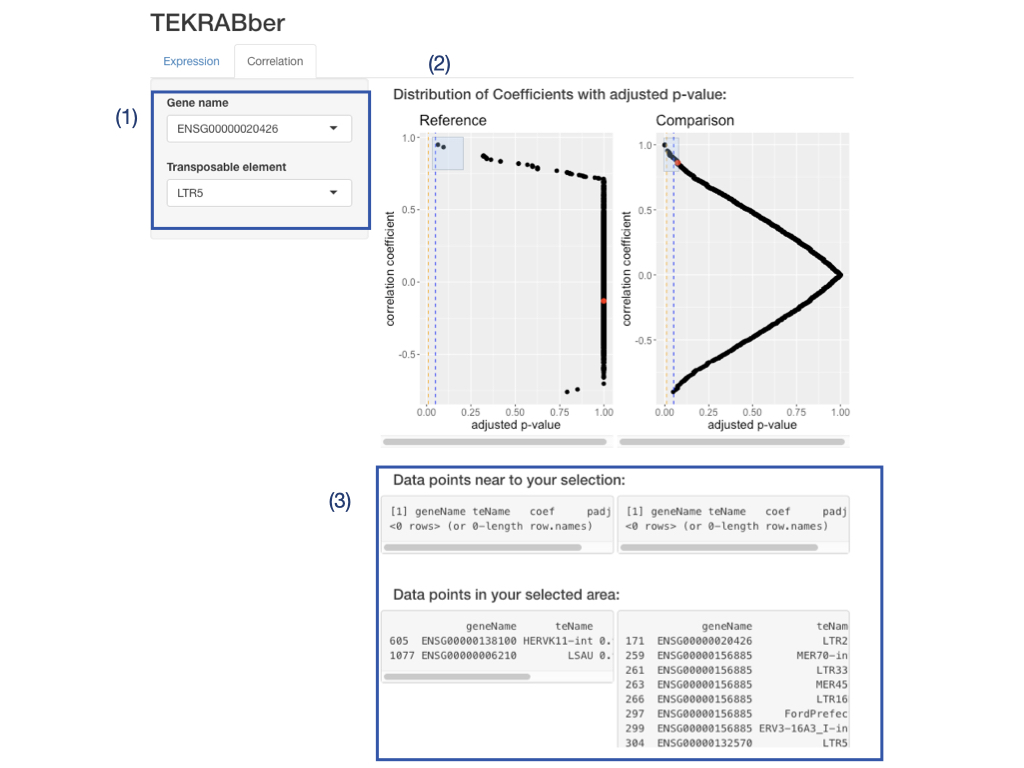

In the **Correlation tab** page, you can visualize your data in scatter plots by three ways. (1) Specify the data point and it will turn red in the distribution of your result (2) Show the distribution of all the data from your correlation results based on their correlation coefficients and adjusted *p-value*. The blue vertical dashed line indicates the boundary of adjusted *p-value* is 0.05, and the orange one is for adjusted *p-value* 0.01 (3) you can click the data points which you are interested in and it will list in the table. You can also drag an area to show data points in certain area.

## 3.2 Comparing control and treatment samples within the same species

```r
# load built-in data
data(ctInputDE)
geneInputDE <- ctInputDE$gene
teInputDE <- ctInputDE$te

# you need to follow the input format as below
head(geneInputDE)
```

```
##                 control_1 control_2 control_3 control_4 control_5 treatment_6
## ENSG00000180263      1470      2072      1864      2238      2246        2599
## ENSG00000185985      1599      1045       946      1642      2199         665
## ENSG00000144355       517       380      1211       812        48         388
## ENSG00000234003         4         4        14        10         5           9
## ENSG00000257342         1         1         1         2         3           3
## ENSG00000223953       259       830       133       258       850         504
##                 treatment_7 treatment_8 treatment_9 treatment_10
## ENSG00000180263        2679        2562        2532         2682
## ENSG00000185985        1023        2477        1423         1731
## ENSG00000144355         275         633          59          248
## ENSG00000234003           4          18          13           22
## ENSG00000257342           0           6           1            5
## ENSG00000223953        1143        1500         498          864
```

### 3.2.1 DE analysis

For DE analysis in the same species, you also use `DEgeneTE()` function, however, you need to set the parameter **expDesign** to **FALSE**. You also need to provide a metadata which this time the column name must be **experiment**. See demo below:

```r
metaExp <- data.frame(experiment = c(rep("control", 5), rep("treatment", 5)))
rownames(metaExp) <- colnames(geneInputDE)
metaExp$experiment <- factor(metaExp$experiment, levels = c("control", "treatment"))

resultDE <- DEgeneTE(
  geneTable = geneInputDE,
  teTable = teInputDE,
  metadata = metaExp,
  contrastVector = c("experiment", "control", "treatment"),
  expDesign = FALSE
)
```

### 3.2.2 Correlation analysis

For a quick demo to perform correlation of genes and TEs in control and treatment sample, we use a relatively small input table which only include 10 genes and 10 TEs.

```r
# load built-in data
data(ctCorr)
geneConCorrInput <- assay_tekcorrset(ctCorr, "gene", "control")
teConCorrInput <- assay_tekcorrset(ctCorr, "te", "control")
geneTreatCorrInput <- assay_tekcorrset(ctCorr, "gene", "treatment")
teTreatCorrInput <- assay_tekcorrset(ctCorr, "te", "treatment")

# you need to follow the input format as below
head(geneConCorrInput)
```

```
##                 control_1 control_2 control_3 control_4 control_5
## ENSG00000180263      1470      2072      1864      2238      2246
## ENSG00000185985      1599      1045       946      1642      2199
## ENSG00000144355       517       380      1211       812        48
## ENSG00000234003         4         4        14        10         5
## ENSG00000257342         1         1         1         2         3
## ENSG00000223953       259       830       133       258       850
```

```r
controlCorr <- corrOrthologTE(
    geneInput = geneConCorrInput,
    teInput = teConCorrInput,
    corrMethod = "pearson",
    padjMethod = "fdr",
    filename = "controlCorrResult.csv"
)

treatmentCorr <- corrOrthologTE(
    geneInput = geneTreatCorrInput,
    teInput = teTreatCorrInput,
    corrMethod = "pearson",
    padjMethod = "fdr",
    filename = "treatmentCorrResult.csv"
)

head(treatmentCorr)
```

```
##          geneName teName    pvalue       coef      padj
## 1 ENSG00000180263    ALU 0.7350708 -0.2096204 0.8750842
## 2 ENSG00000180263  AluJb 0.6463988 -0.2814802 0.8729353
## 3 ENSG00000180263  AluJo 0.5879945 -0.3296607 0.8399922
## 4 ENSG00000180263  AluJr 0.6080013 -0.3130670 0.8563399
## 5 ENSG00000180263 AluJr4 0.7158070 -0.2251209 0.8729353
## 6 ENSG00000180263  AluSc 0.7130150 -0.2273721 0.8729353
```

### 3.2.3 Explore your result using appTEKRABber():

```r
appTEKRABber(
  DEresult = resultDE,
  corrRef = controlCorr,
  corrCompare = treatmentCorr,
  metadata = metaExp
)
```